# Report 1

Barbara Chen

2023-06-08

This report will analyze the distribution of prices, sales, and revenue of 700 coffee table-related products on Amazon. The keywords used to gather these products are “*coffee table, nightstand, side table, end table, bedside table, sofa table, living room table, and accent table*”.

The top 120 listings for each results were gathered from Helium10 Xray, which among many things, provided the sales and revenue estimations for each product. Because revenue is only an estimation from Helium10, it is not 100% reliable. This should be kept in mind for the rest of the analysis.

The sponsored posts were removed. Duplicated listings (products which showed up for different search terms) were also removed.

74 items did not have sales and revenue estimations, so those products were left out in the analyses related to sales and revenue.

The goal is to determine if there is any correlation between price, sales, and revenue.

## Conclusion

1. There is no strong correlation between prices and sales, and prices and revenue.

#### Revenue

1. 10% of the products generated much higher revenue ( > $100,000) compared to the rest.
2. 75% of the products generated less than $56,000.
3. 25% of the products generated less than $11,000.

#### Price

1. 98% of the products are less than $300. Anything more than that generated low revenue.
2. Prices over $160 could be considered too high,
3. 75% of the products are less than $90. The market for cheaper products (< $90) could be really competitive.

### Recommendations (for now…)

1. Price of $160 is considered very high compared with all the products (could be risky to have a product in this range).
2. If aiming for mid-high prices, $90~$160 could be a good range. The products in this price range were *slightly* more likely to generate higher revenue. Moreover, there is less competition in this price range.
3. If aiming for mid-low prices (<$90), expect more competition.

## 0. Overview of Price, Sales, and Revenue

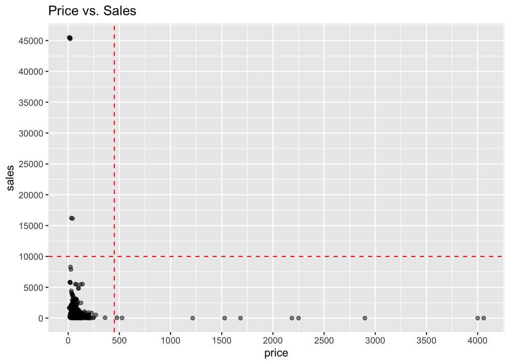

Here, we can clearly see a cluster in the lower left corner where the bulk of the data lies. For analysis later, we will zoom in to price < $450 and sales < $10,000.

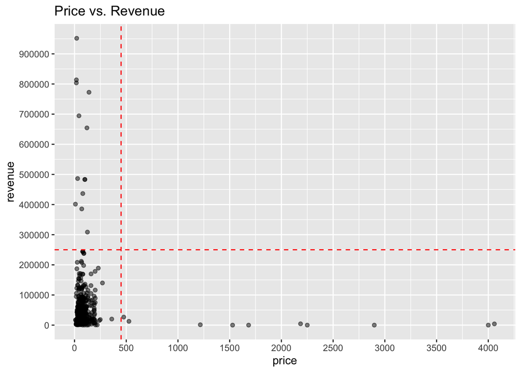

Again, we see a cluster in the lower left corner. We will zoom in to price < $ 450 and revenue < $250,000.

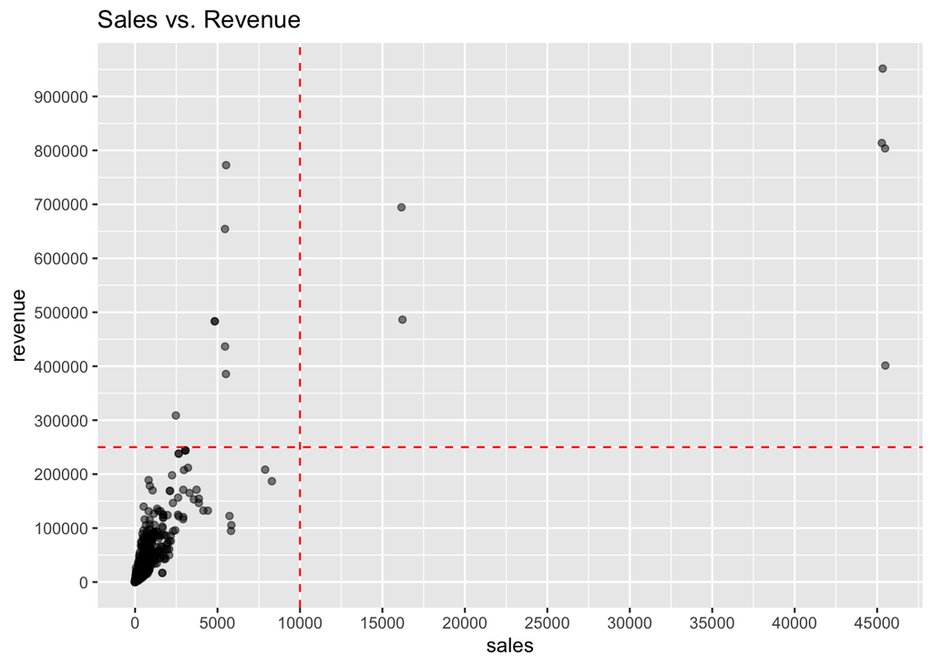

The following will be the ranges we look at for the next part of the analysis.

1. Price < $450
2. Sales < 10,000
3. Revenue < $250,000

Anything outside will be considered extreme values, which will be further examined.

### 0.1 Correlation

```
##         price sales revenue
## price    1.00 -0.05   -0.06
## sales   -0.05  1.00    0.78
## revenue -0.06  0.78    1.00
```

## 1. Revenue Distribution

74 products were missing revenue information, so those products will not be included in this part of the analysis.

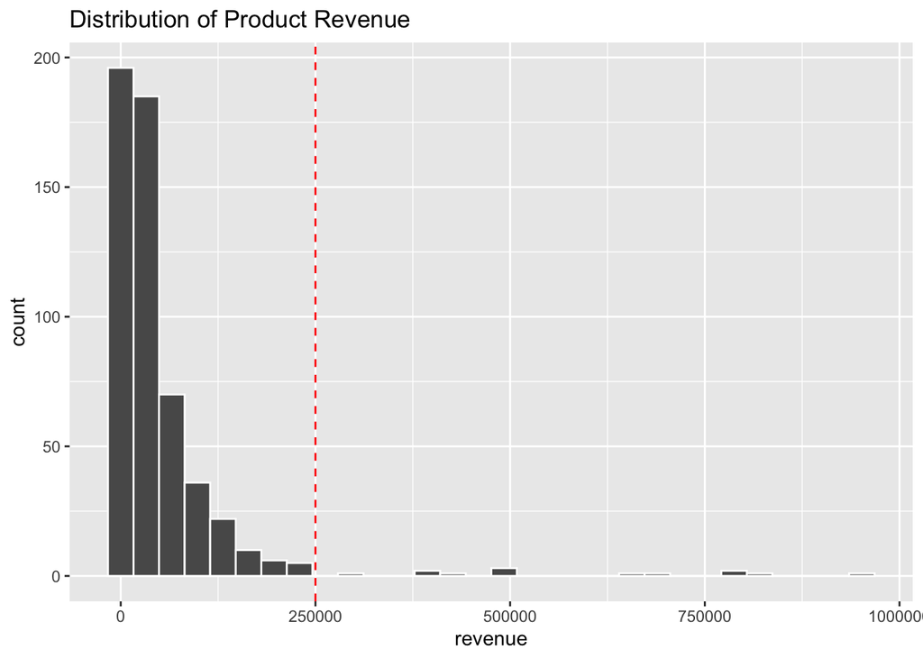

Again, we can see quite a few extremes (>250000)

### 1.1 Revenue (No Extremes)

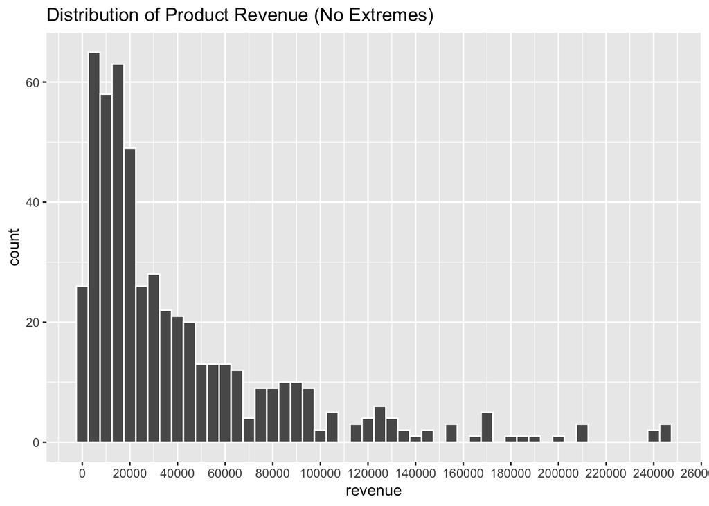

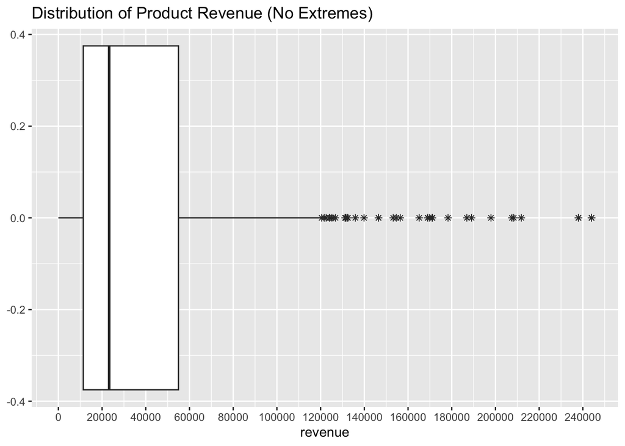

```
##        0%       25%       50%       75%      100%
##      0.00  11608.71  24737.57  58008.18 951644.62
```

### 1.2 Revenue Outliers

```
## [1] "Revenue outliers: > $127607.3725"
```

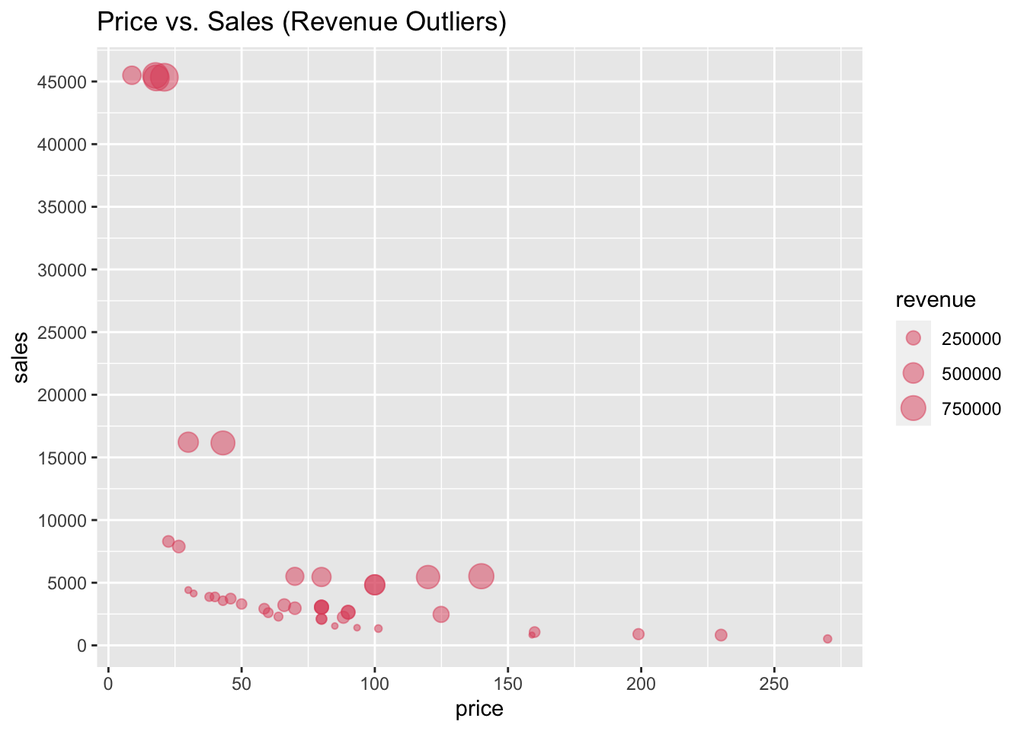

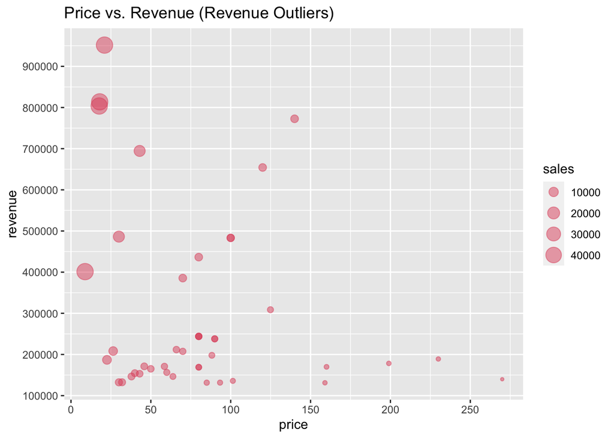

## 2. Price Distribution

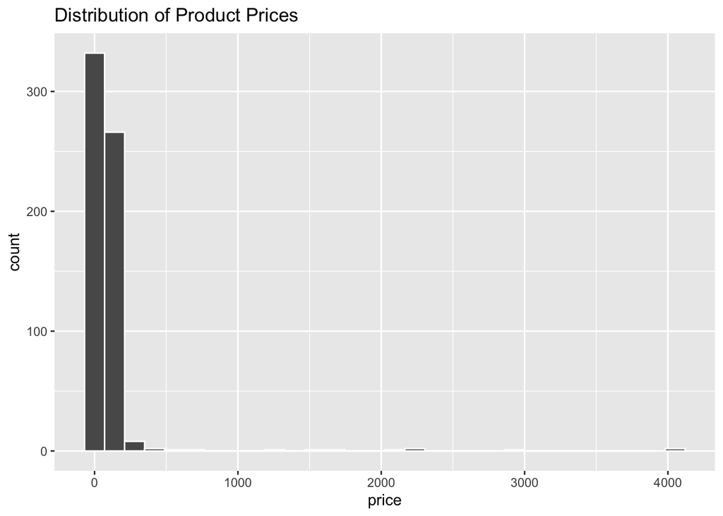

From this, we can clearly see some extreme values ( price > $ 450). We will go ahead and filter that out.

**Products for which price > $ 450 will be removed (12 products).** These will be examined in more detail later along with actual outliers.

```
## [1] 12
```

### 2.1 Prices (No Extremes)

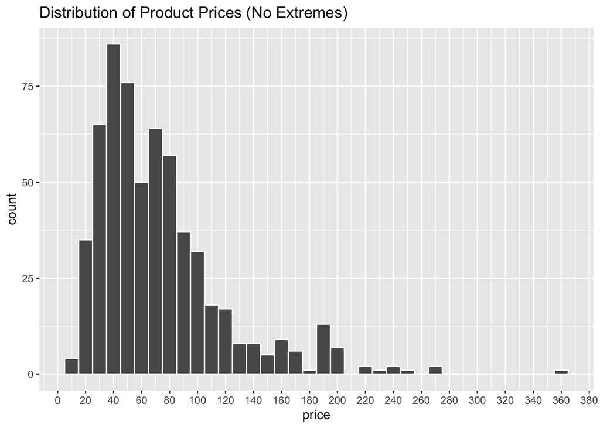

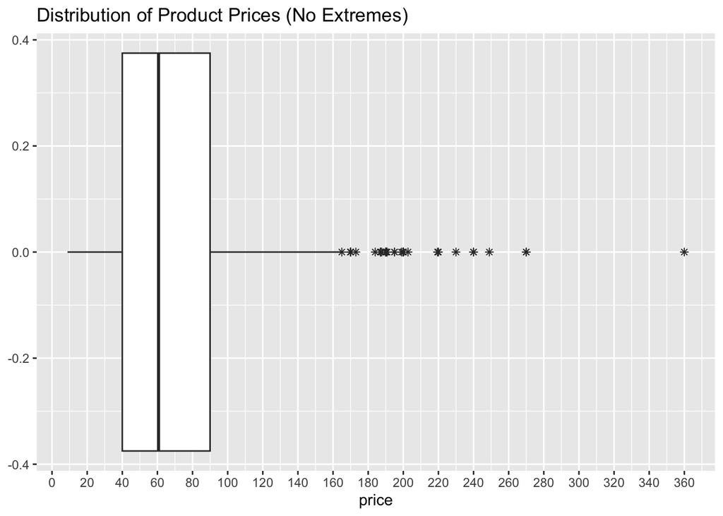

Below is the five-number summary of the prices.

```
##      0%     25%     50%     75%    100%
##    8.82   39.99   63.95   89.99 4059.00
```

#### Observations

1. The middle 50% of the data is around $ 40 to $ 90.
2. Top 25% of products is priced above $ 90.
3. Technically, any products priced above $ 160 would be considered an outlier.

### 2.2 Prices Outliers

```
## [1] "Price outliers: > $164.99"
```

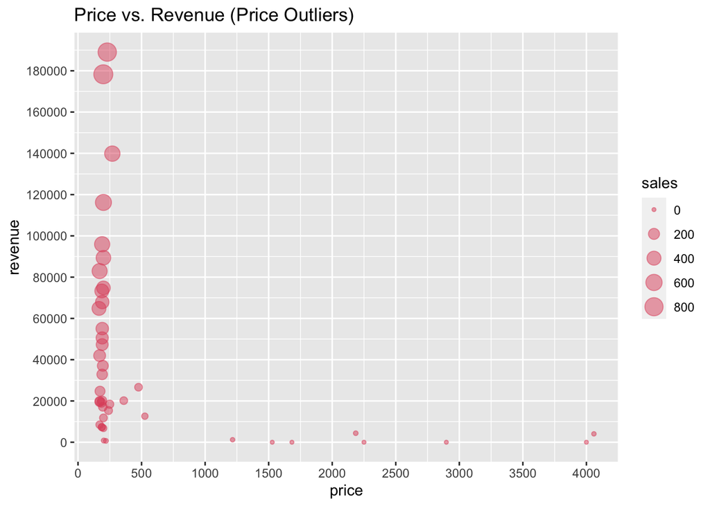

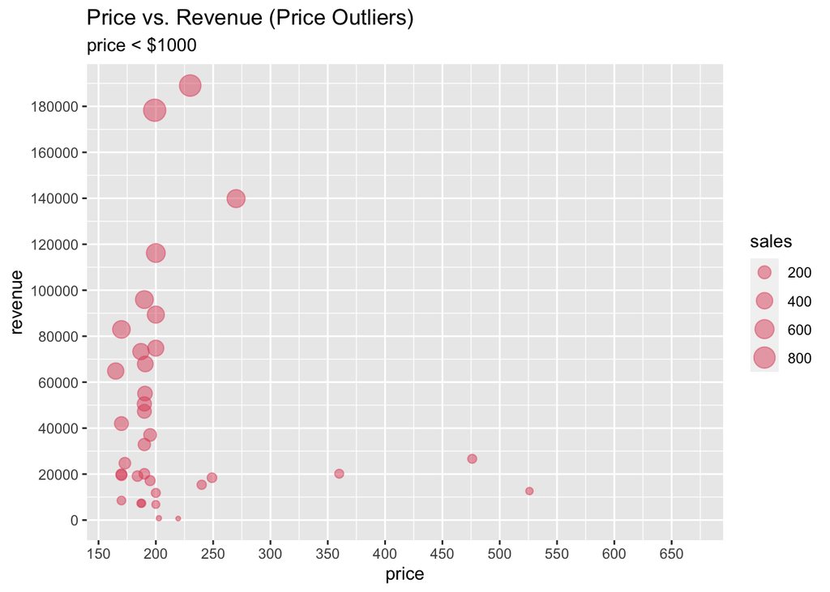

#### Observations

1. Products with price > $1000 have extremely low revenue. In other words, avoid listing products above $1000.
2. Products with price ranging from $350 ~ $550 have relatively lower revenue.
3. Products with price < $350 ~ $550 have varying levels of revenue.

## 3. Sales Distribution

74 products were missing sales information, so those products will not be included in this part of the analysis.

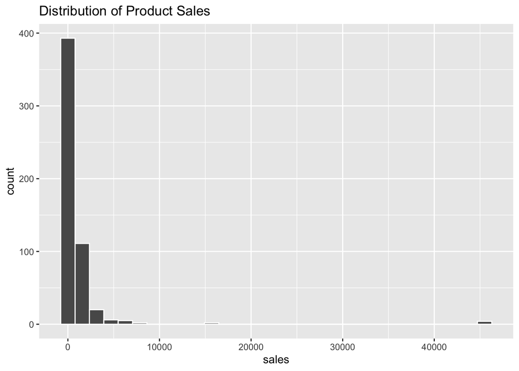

**Products in which number of sales > 10000 will be removed (6 products).** These will be examined in more detail later along with actual outliers.

### 3.1 Sales (No Extremes)

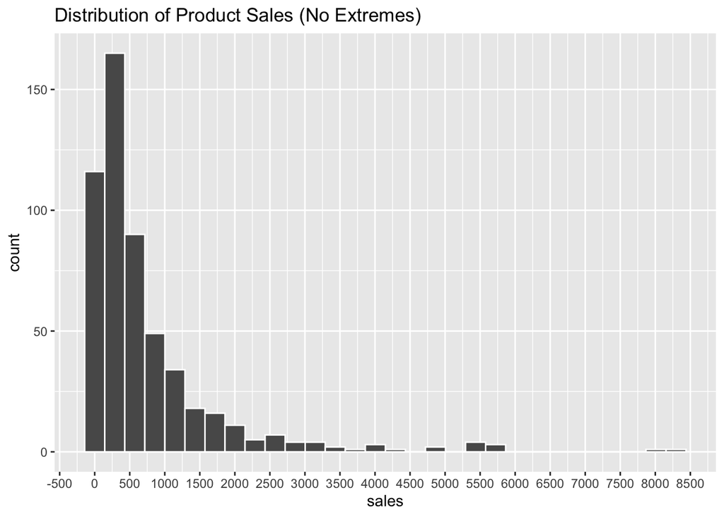

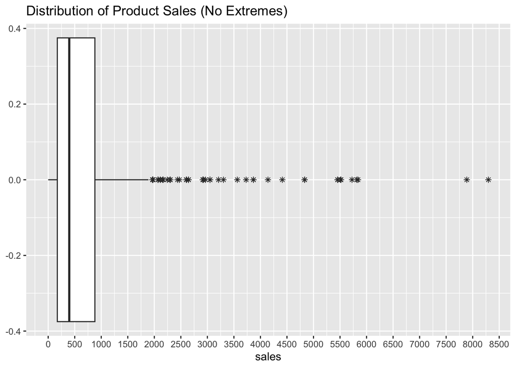

```
##    0%   25%   50%   75%  100%
##     0   173   411   890 45497
```

### 3.2 Sales Outliers

```
## [1] "Sales outliers: > 1965.5"
```

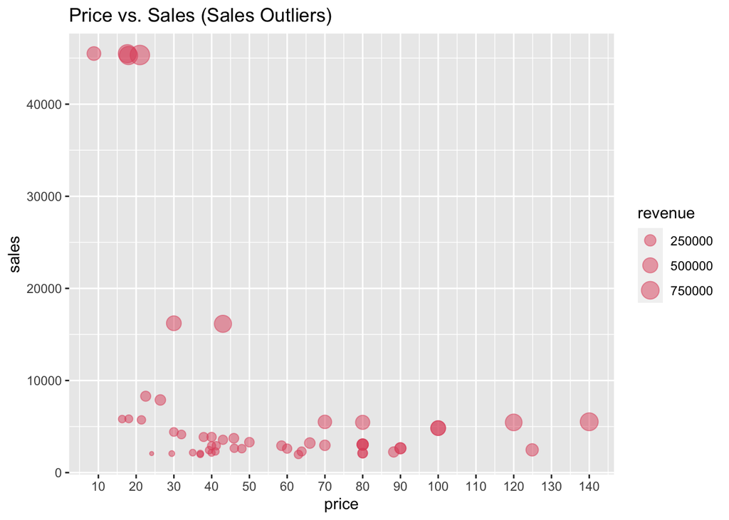

## 4. Price, Sales, Revenue

Now, we will examine the relationship between prices, sales and revenue. We will filter out price > $ 1000 since these products generate insignificant revenue.

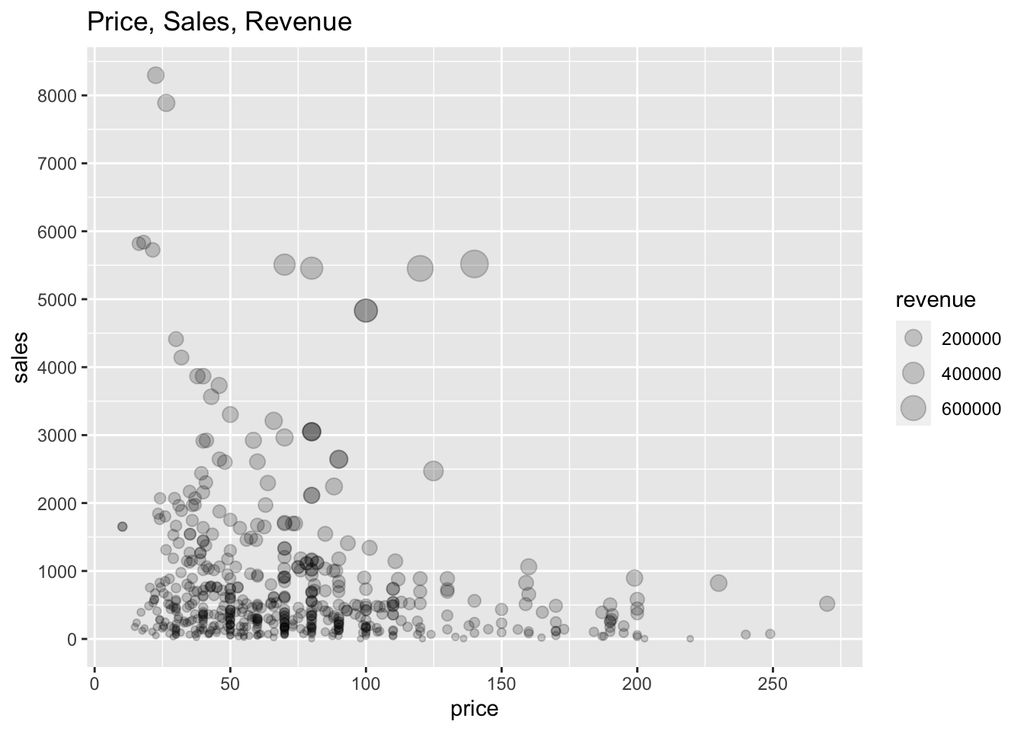

#### Observation 1. As we already know, high sales = high revenue 2. ALSO: low sales **+ higher price** = high revenue. 3. We see that while products over $100 have lower number of sales, they still generate relatively high revenue.

### 4.1 Price vs. Revenue

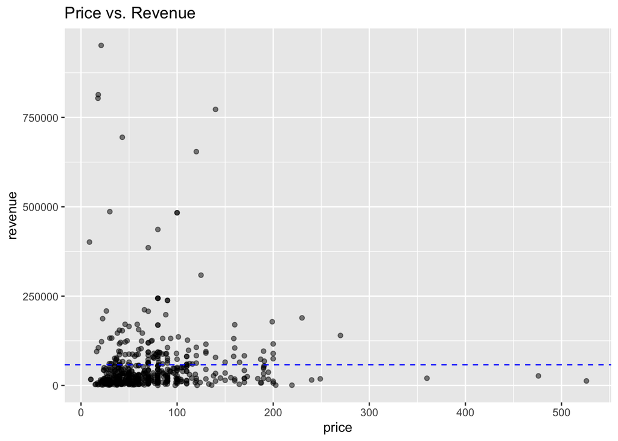

#### Observations

1. There is a clear cluster in terms of product price. The first cluster is less than $100, and the second is between $100 and $300.
2. Products more than $300 tend to have relatively low revenue (with a couple exceptions).
3. If we just look at the top 25% revenue, we also see more products less than $100.

## 5. Price Groups

Earlier, we identified two clusters of price ranges. Based on the natural clustering and the quantiles, I decided to define three price ranges.

The lower price range is around $0 to $90. (lower 75% of the products) The second price range is around $90 dollars to $160. The third range is $160 and above. (outliers)

Let’s examine each of these groups.

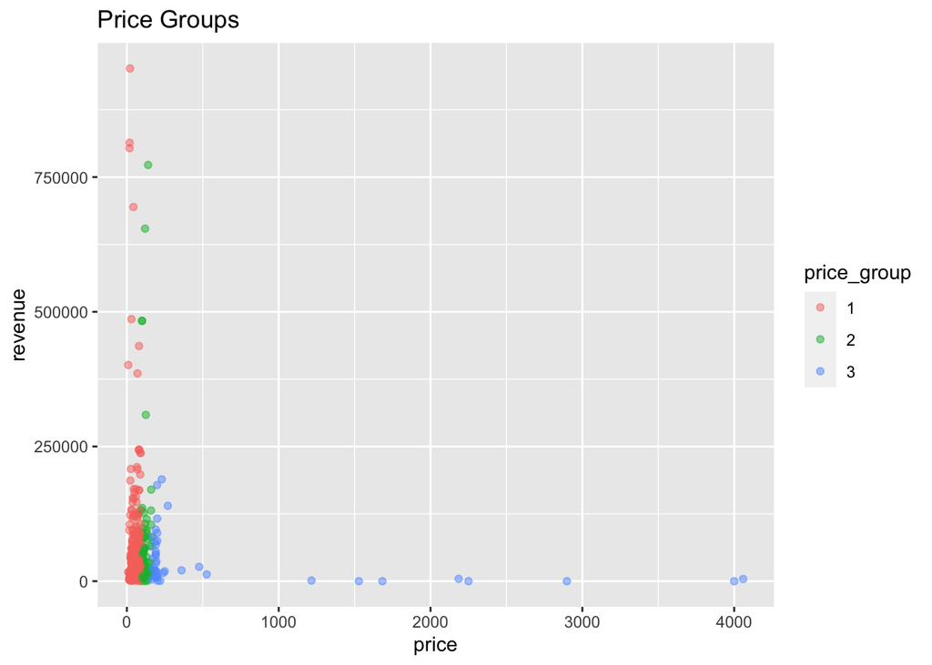

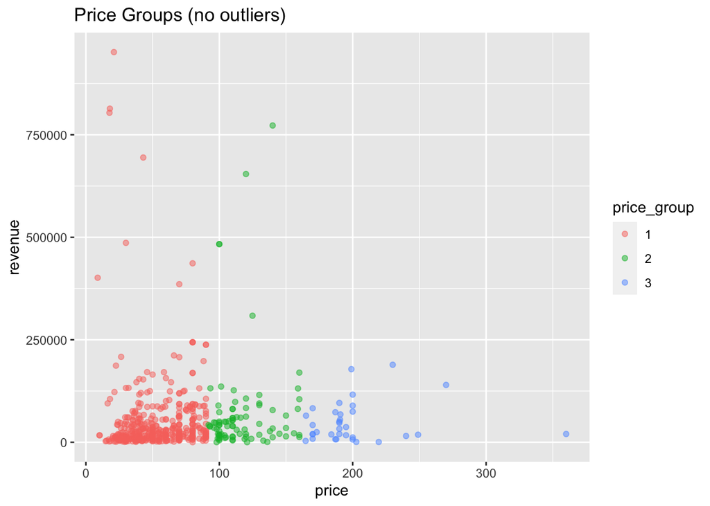

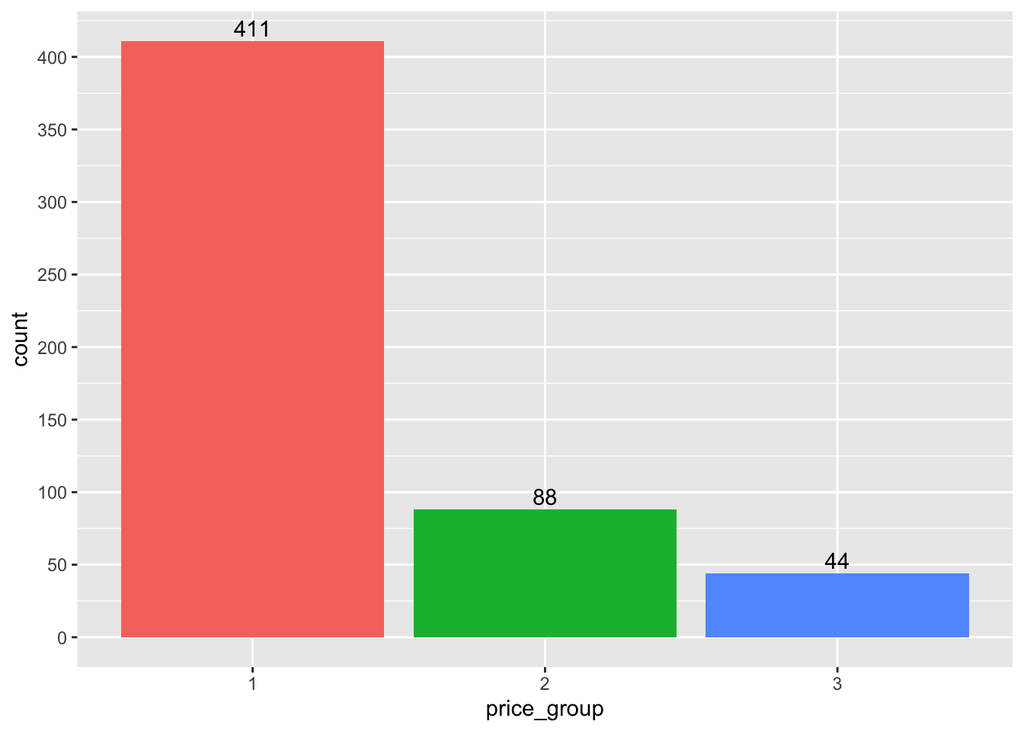

Note that group 1 represents 75% of the data.

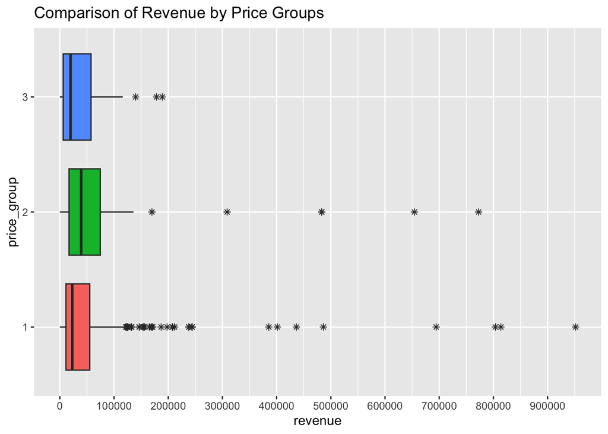

#### Observations

1. By comparing the revenue of different groups, more products in group 2 ($90 ~ $160) generate higher revenue.
2. Top 25% of the products in group 2 generated more than $73,000 (compared to the overall 25% - $56,000).

## 6. Revenue Groups

We will analyze in terms of revenue quartiles:

1. q1: <$11,159 (lowest revenue group)
2. q2: $11,159 ~ $23,319
3. q3: $23,319 ~ $56,450
4. q4: > $56,450 (highest revenue group)

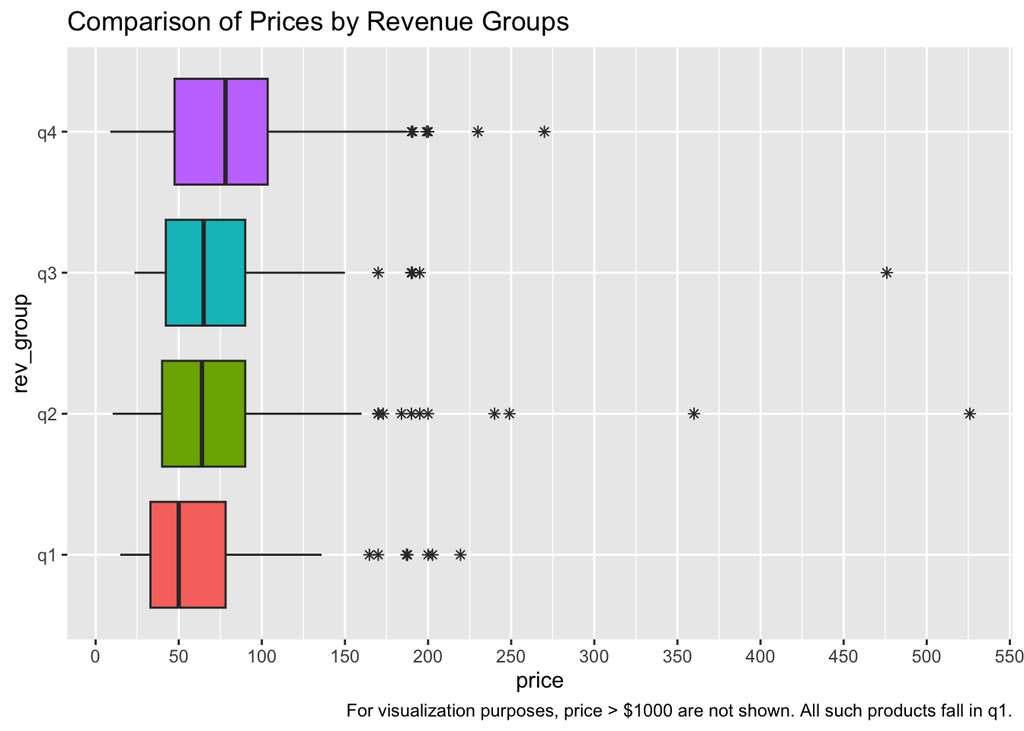

#### Observations

1. Higher revenue groups (q4, q3, and q2) have *slightly* more products above $90 compared to the lowest revenue groups (q1).
2. q3 and q2 have similar distribution.
3. Products less than $90 are almost equally likely to be in any revenue group.
4. Products above $90 are a little more likely to be in the higher revenue groups (q2, q3, q4)